# EXST-7142 Project

### Exploring the Titanic Dataset

#### Mark Behl

# Problem Description

**from Kaggle:**

"The sinking of the Titanic is one of the most infamous shipwrecks in history.  
On April 15, 1912, during her maiden voyage, the widely considered “unsinkable” RMS Titanic sank after colliding with an iceberg. Unfortunately, there weren’t enough lifeboats for everyone onboard, resulting in the death of 1502 out of 2224 passengers and crew.  
While there was some element of luck involved in surviving, it seems some groups of people were more likely to survive than others.  
In this challenge, we ask you to build a predictive model that answers the question: “what sorts of people were more likely to survive?” using passenger data (ie name, age, gender, socio-economic class, etc)."

[figure not shown]

```python
# Loading necessary libraries for data manipulation and plotting

import numpy as np
import pandas as pd

import seaborn as sns
import matplotlib.pyplot as plt
%matplotlib inline

np.random.seed(0)
```

# Data description and cleaning

[figure not shown]

Data from Kaggle is already split into training and testing sets.

- **Training set:**

Contains data for 891 passengers

- **Test set:**

Contains data for 418 passengers

**Test set has unknown labels, so training set will be used solely for model building and evaluation**

```python
# import data
train = pd.read_csv('train.csv')
test = pd.read_csv('test.csv')
```

## Data column meanings

| VARIABLE | DESCRIPTION |
| --- | --- |
| PassengerId | Unique ID of the passenger |
| Survived | (0 = No; 1 = Yes) |
| Pclass | Passenger Class (1 = 1st; 2 = 2nd; 3 = 3rd) |
| Name | Name |
| Sex | Sex |
| Age | Age |
| SibSp | Number of Siblings/Spouses Aboard |
| Parch | Number of Parents/Children Aboard |
| Ticket | Ticket Number |
| Fare | Passenger Fare (British pound) |
| Cabin | Cabin |
| Embarked | Port of Embarkation (C = Cherbourg; Q = Queenstown; S = Southampton) |

```python
# Training data summary
print(train.describe(),'\n')
print(train.describe(include='O'))
```

```
       PassengerId    Survived      Pclass         Age       SibSp  \
count   891.000000  891.000000  891.000000  714.000000  891.000000
mean    446.000000    0.383838    2.308642   29.699118    0.523008
std     257.353842    0.486592    0.836071   14.526497    1.102743
min       1.000000    0.000000    1.000000    0.420000    0.000000
25%     223.500000    0.000000    2.000000   20.125000    0.000000
50%     446.000000    0.000000    3.000000   28.000000    0.000000
75%     668.500000    1.000000    3.000000   38.000000    1.000000
max     891.000000    1.000000    3.000000   80.000000    8.000000

            Parch        Fare
count  891.000000  891.000000
mean     0.381594   32.204208
std      0.806057   49.693429
min      0.000000    0.000000
25%      0.000000    7.910400
50%      0.000000   14.454200
75%      0.000000   31.000000
max      6.000000  512.329200

                             Name   Sex    Ticket Cabin Embarked
count                         891   891       891   204      889
unique                        891     2       681   147        3
top     Marvin, Mr. Daniel Warner  male  CA. 2343    G6        S
freq                            1   577         7     4      644
```

### Looking at the most expensive fare

```python
train[train['Fare']==512.3292]
```

|  | PassengerId | Survived | Pclass | Name | Sex | Age | SibSp | Parch | Ticket | Fare | Cabin | Embarked |
| --- | --- | --- | --- | --- | --- | --- | --- | --- | --- | --- | --- | --- |
| 258 | 259 | 1 | 1 | Ward, Miss. Anna | female | 35.0 | 0 | 0 | PC 17755 | 512.3292 | NaN | C |
| 679 | 680 | 1 | 1 | Cardeza, Mr. Thomas Drake Martinez | male | 36.0 | 0 | 1 | PC 17755 | 512.3292 | B51 B53 B55 | C |
| 737 | 738 | 1 | 1 | Lesurer, Mr. Gustave J | male | 35.0 | 0 | 0 | PC 17755 | 512.3292 | B101 | C |

```python
test[test['Fare']==512.3292]
```

|  | PassengerId | Pclass | Name | Sex | Age | SibSp | Parch | Ticket | Fare | Cabin | Embarked |
| --- | --- | --- | --- | --- | --- | --- | --- | --- | --- | --- | --- |
| 343 | 1235 | 1 | Cardeza, Mrs. James Warburton Martinez (Charlo... | female | 58.0 | 0 | 1 | PC 17755 | 512.3292 | B51 B53 B55 | C |

```python
train[train['Cabin']=='B51 B53 B55']
```

|  | PassengerId | Survived | Pclass | Name | Sex | Age | SibSp | Parch | Ticket | Fare | Cabin | Embarked |
| --- | --- | --- | --- | --- | --- | --- | --- | --- | --- | --- | --- | --- |
| 679 | 680 | 1 | 1 | Cardeza, Mr. Thomas Drake Martinez | male | 36.0 | 0 | 1 | PC 17755 | 512.3292 | B51 B53 B55 | C |
| 872 | 873 | 0 | 1 | Carlsson, Mr. Frans Olof | male | 33.0 | 0 | 0 | 695 | 5.0000 | B51 B53 B55 | S |

His occupation was noted as mate sailing vessel. In April 1912 he was to join the American Line's St Louis but because of the coal strike the ship was stuck in Southampton so the company gave him a first class ticket back to New York on Titanic.

### Looking for nulls and variable type descriptions

```python
train.info()
print('_'*40,'\n')
test.info()
```

```
<class 'pandas.core.frame.DataFrame'>
RangeIndex: 891 entries, 0 to 890
Data columns (total 12 columns):
PassengerId    891 non-null int64
Survived       891 non-null int64
Pclass         891 non-null int64
Name           891 non-null object
Sex            891 non-null object
Age            714 non-null float64
SibSp          891 non-null int64
Parch          891 non-null int64
Ticket         891 non-null object
Fare           891 non-null float64
Cabin          204 non-null object
Embarked       889 non-null object
dtypes: float64(2), int64(5), object(5)
memory usage: 83.7+ KB
________________________________________

<class 'pandas.core.frame.DataFrame'>
RangeIndex: 418 entries, 0 to 417
Data columns (total 11 columns):
PassengerId    418 non-null int64
Pclass         418 non-null int64
Name           418 non-null object
Sex            418 non-null object
Age            332 non-null float64
SibSp          418 non-null int64
Parch          418 non-null int64
Ticket         418 non-null object
Fare           417 non-null float64
Cabin          91 non-null object
Embarked       418 non-null object
dtypes: float64(2), int64(4), object(5)
memory usage: 36.0+ KB
```

```
(891.5, -0.5)
```

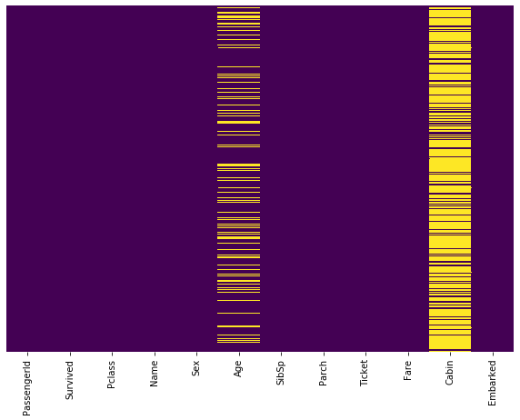

```python
plt.figure(figsize=(10,7))
ax = sns.heatmap(train.isnull(),yticklabels=False,cbar=False,cmap='viridis')
bottom, top = ax.get_ylim()
ax.set_ylim(bottom + 0.5, top - 0.5)
```

We can see that there are null values that need to be taken care of. 80% of rows have null values in 'Cabin' column, so this column will be removed in both sets.

```python
train.drop('Cabin', axis=1, inplace=True)
test.drop('Cabin', axis=1, inplace=True)
```

```python
sum(train['Age'].isnull()) / len(train)
```

```
0.19865319865319866
```

### Only 20% of rows have nulls in 'Age' column. Will try to impute values

```
(7.0, 0.0)
```

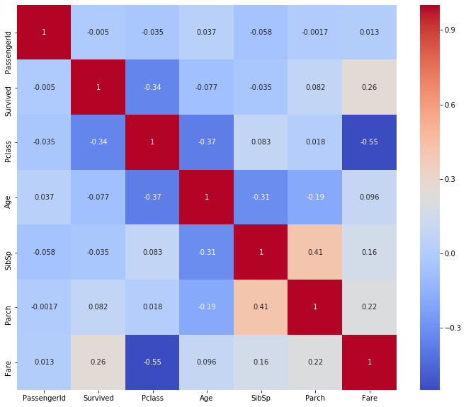

```python
plt.figure(figsize=(12,10))
ax = sns.heatmap(train.corr(), cmap='coolwarm', annot=True)
bottom, top = ax.get_ylim()
ax.set_ylim(bottom + 0.5, top - 0.5)
```

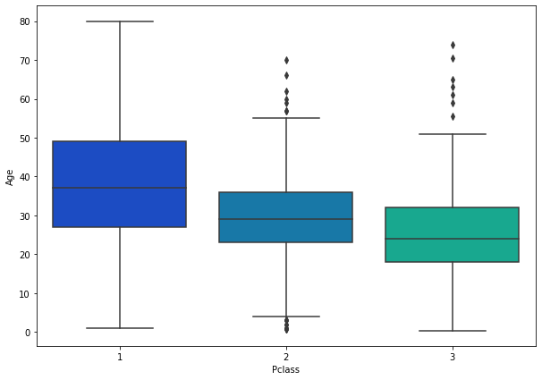

```python
plt.figure(figsize=(10, 7))
sns.boxplot(x='Pclass',y='Age',data=train,palette='winter')
```

### Imputing Age based on average for respective Pclass seems reasonable

```python
mean1 = train[train['Pclass']==1]['Age'].median()
mean2 = train[train['Pclass']==2]['Age'].median()
mean3 = train[train['Pclass']==3]['Age'].median()


def impute_age(cols):
    Age = cols[0]
    Pclass = cols[1]

    if pd.isnull(Age):

        if Pclass == 1:
            return mean1

        elif Pclass == 2:
            return mean2

        else:
            return mean3

    else:
        return Age
```

```python
train['Age'] = train[['Age','Pclass']].apply(impute_age,axis=1)
test['Age'] = test[['Age','Pclass']].apply(impute_age,axis=1)
```

```python
train[train['Embarked'].isnull()]
```

|  | PassengerId | Survived | Pclass | Name | Sex | Age | SibSp | Parch | Ticket | Fare | Embarked |
| --- | --- | --- | --- | --- | --- | --- | --- | --- | --- | --- | --- |
| 61 | 62 | 1 | 1 | Icard, Miss. Amelie | female | 38.0 | 0 | 0 | 113572 | 80.0 | NaN |
| 829 | 830 | 1 | 1 | Stone, Mrs. George Nelson (Martha Evelyn) | female | 62.0 | 0 | 0 | 113572 | 80.0 | NaN |

```python
# dropping the few entries with null in 'Embarked'
train.dropna(inplace=True)
```

## further cleaning and feature engineering from examples taken from Kaggle learning

```python
combine=[train,test]
for dataset in combine:
    dataset['Title'] = dataset.Name.str.extract(' ([A-Za-z]+)\.', expand=False)
    dataset['Title'] = dataset['Title'].replace(['Lady', 'Countess','Capt', 'Col',
                                                 'Don', 'Dr', 'Major', 'Rev', 'Sir', 'Jonkheer', 'Dona'], 'Rare')

    dataset['Title'] = dataset['Title'].replace('Mlle', 'Miss')
    dataset['Title'] = dataset['Title'].replace('Ms', 'Miss')
    dataset['Title'] = dataset['Title'].replace('Mme', 'Mrs')
```

```python
title_mapping = {"Mr": 1, "Miss": 2, "Mrs": 3, "Master": 4, "Rare": 5}
for dataset in combine:
    dataset['Title'] = dataset['Title'].map(title_mapping)
    dataset['Title'] = dataset['Title'].fillna(0)
```

```python
train = train.drop(['Name', 'PassengerId'], axis=1)
test = test.drop(['Name'], axis=1)
combine = [train, test]
train.shape, test.shape
```

```
((889, 10), (418, 10))
```

```python
#'Sex'
for dataset in combine:
    dataset['Sex'] = dataset['Sex'].map( {'female': 1, 'male': 0} ).astype(int)
```

```python
#'Age'
train['AgeBand'] = pd.cut(train['Age'], 5)
train[['AgeBand', 'Survived']].groupby(['AgeBand'], as_index=False).mean().sort_values(by='AgeBand', ascending=True)
```

|  | AgeBand | Survived |
| --- | --- | --- |
| 0 | (0.34, 16.336] | 0.550000 |
| 1 | (16.336, 32.252] | 0.336714 |
| 2 | (32.252, 48.168] | 0.410138 |
| 3 | (48.168, 64.084] | 0.426471 |
| 4 | (64.084, 80.0] | 0.090909 |

```python
#replacing age values with ordinals based on AgeBand
for dataset in combine:
    dataset.loc[ dataset['Age'] <= 16, 'Age'] = 0
    dataset.loc[(dataset['Age'] > 16) & (dataset['Age'] <= 32), 'Age'] = 1
    dataset.loc[(dataset['Age'] > 32) & (dataset['Age'] <= 48), 'Age'] = 2
    dataset.loc[(dataset['Age'] > 48) & (dataset['Age'] <= 64), 'Age'] = 3
    dataset.loc[ dataset['Age'] > 64, 'Age']

train = train.drop(['AgeBand'], axis=1)
combine = [train, test]
```

```python
# 'SibSp' and 'Parch'
for dataset in combine:
    dataset['FamilySize'] = dataset['SibSp'] + dataset['Parch'] + 1

train[['FamilySize', 'Survived']].groupby(['FamilySize'], as_index=False).mean().sort_values(by='Survived', ascending=False)
```

|  | FamilySize | Survived |
| --- | --- | --- |
| 3 | 4 | 0.724138 |
| 2 | 3 | 0.578431 |
| 1 | 2 | 0.552795 |
| 6 | 7 | 0.333333 |
| 0 | 1 | 0.300935 |
| 4 | 5 | 0.200000 |
| 5 | 6 | 0.136364 |
| 7 | 8 | 0.000000 |
| 8 | 11 | 0.000000 |

```python
for dataset in combine:
    dataset['IsAlone'] = 0
    dataset.loc[dataset['FamilySize'] == 1, 'IsAlone'] = 1

train[['IsAlone', 'Survived']].groupby(['IsAlone'], as_index=False).mean()
```

|  | IsAlone | Survived |
| --- | --- | --- |
| 0 | 0 | 0.505650 |
| 1 | 1 | 0.300935 |

```python
train = train.drop(['Parch', 'SibSp', 'FamilySize','Ticket'], axis=1)
test = test.drop(['Parch', 'SibSp', 'FamilySize','Ticket'], axis=1)
combine = [train, test]
```

```python
#embarked
for dataset in combine:
    dataset['Embarked'] = dataset['Embarked'].map( {'S': 0, 'C': 1, 'Q': 2} ).astype(int)
```

# Further exploratory analysis and visualization

[figure not shown]

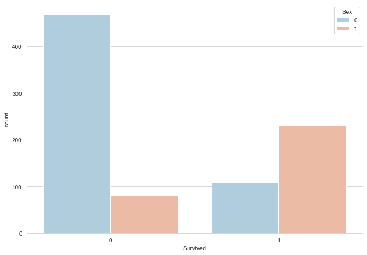

```python
plt.figure(figsize=(10,7))
sns.set_style('whitegrid')
sns.countplot(x='Survived',hue='Sex',data=train,palette='RdBu_r')
```

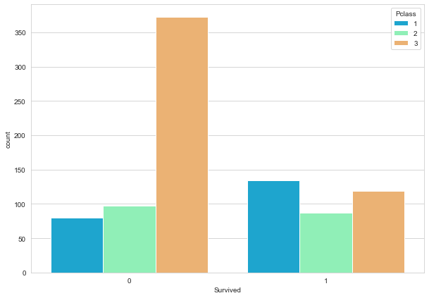

```python
plt.figure(figsize=(10,7))
sns.set_style('whitegrid')
sns.countplot(x='Survived',hue='Pclass',data=train,palette='rainbow')
```

# Modeling

[figure not shown]

```python
X = train.drop(["Survived"], axis=1)
y = train["Survived"]
```

## Logistic Regression

```python
from sklearn.model_selection import train_test_split
from sklearn.metrics import classification_report, accuracy_score, confusion_matrix
from sklearn.linear_model import LogisticRegressionCV
```

```python
X_train, X_test, y_train, y_test = train_test_split(X, y, test_size=0.2, random_state=0)
```

```python
# Use K fold cross validation to optimize model
for i in range(2,11):
    clf = LogisticRegressionCV(cv=i,random_state=0,max_iter=200).fit(X_train, y_train)
    print(i,'folds:',clf.score(X_train,y_train))
```

```
2 folds: 0.8129395218002813
3 folds: 0.8059071729957806
4 folds: 0.8059071729957806
5 folds: 0.8241912798874824
6 folds: 0.8213783403656821
7 folds: 0.8213783403656821
8 folds: 0.8213783403656821
9 folds: 0.8241912798874824
10 folds: 0.8213783403656821
```

### Optimum number of folds is 5

```python
clf = LogisticRegressionCV(cv=5,random_state=0, max_iter=200).fit(X_train, y_train)
pred = clf.predict(X_test)
```

```python
pd.crosstab(y_test,pred,rownames=['Actual'], colnames=['Predicted'])
```

| Predicted Actual | 0 | 1 |
| --- | --- | --- |
| 0 | 86 | 19 |
| 1 | 26 | 47 |

```python
print("Accuracy: ",clf.score(X_test,y_test))
```

```
Accuracy:  0.7471910112359551
```

```python
print(clf.coef_)
print(X_train.columns)
```

```
[[-0.59577106  1.18821605 -0.03228702  0.00405095  0.33066468  0.56690244
   0.01940995]]
Index(['Pclass', 'Sex', 'Age', 'Fare', 'Embarked', 'Title', 'IsAlone'], dtype='object')
```

```python
est = sm.Logit(y_train, X_train)
est2 = est.fit()
print(est2.summary())
```

```
Optimization terminated successfully.
         Current function value: 0.419964
         Iterations 7
                           Logit Regression Results
==============================================================================
Dep. Variable:               Survived   No. Observations:                  711
Model:                          Logit   Df Residuals:                      704
Method:                           MLE   Df Model:                            6
Date:                Thu, 31 Oct 2019   Pseudo R-squ.:                  0.3655
Time:                        13:20:28   Log-Likelihood:                -298.59
converged:                       True   LL-Null:                       -470.56
Covariance Type:            nonrobust   LLR p-value:                 3.091e-71
==============================================================================
                 coef    std err          z      P>|z|      [0.025      0.975]
------------------------------------------------------------------------------
Pclass        -1.0943      0.103    -10.603      0.000      -1.297      -0.892
Sex            2.3785      0.237     10.056      0.000       1.915       2.842
Age           -0.0353      0.020     -1.769      0.077      -0.074       0.004
Fare           0.0001      0.002      0.064      0.949      -0.004       0.004
Embarked       0.5363      0.159      3.374      0.001       0.225       0.848
Title          0.4678      0.101      4.647      0.000       0.270       0.665
IsAlone        0.0883      0.198      0.446      0.656      -0.300       0.476
==============================================================================
```

## Decision tree

```python
from sklearn.tree import DecisionTreeClassifier
```

```python
dtclf = DecisionTreeClassifier(random_state=0)
```

```python
dtclf.fit(X_train,y_train)
```

```
DecisionTreeClassifier(class_weight=None, criterion='gini', max_depth=None,
                       max_features=None, max_leaf_nodes=None,
                       min_impurity_decrease=0.0, min_impurity_split=None,
                       min_samples_leaf=1, min_samples_split=2,
                       min_weight_fraction_leaf=0.0, presort=False,
                       random_state=0, splitter='best')
```

```python
pd.DataFrame(dtclf.feature_importances_.reshape(7,1), index=X_train.columns,columns=['Importance'])
```

|  | Importance |
| --- | --- |
| Pclass | 0.103693 |
| Sex | 0.010155 |
| Age | 0.048851 |
| Fare | 0.343091 |
| Embarked | 0.029222 |
| Title | 0.452419 |
| IsAlone | 0.012569 |

```python
from sklearn.model_selection import GridSearchCV
```

```python
parameters = {'min_samples_split':range(3,20),'max_depth':range(2,10)}

clf = GridSearchCV(dtclf,parameters,cv=10,iid=False).fit(X_train,y_train)
dtclf = clf.best_estimator_
print (clf.best_score_, clf.best_params_)
```

```
0.8409423205902078 {'max_depth': 3, 'min_samples_split': 3}
```

```python
pred = dtclf.predict(X_test)
```

```python
pd.crosstab(y_test,pred,rownames=['Actual'], colnames=['Predicted'])
```

| Predicted Actual | 0 | 1 |
| --- | --- | --- |
| 0 | 87 | 18 |
| 1 | 26 | 47 |

```python
print("Accuracy: ",dtclf.score(X_test,y_test))
```

```
Accuracy:  0.7528089887640449
```

## Random Forest

```python
X = train.drop(["Survived"], axis=1)
y = train["Survived"]
```

```python
from sklearn.ensemble import RandomForestClassifier

rf = RandomForestClassifier(random_state=0)
```

```python
rf.fit(X_train,y_train)
```

```
RandomForestClassifier(bootstrap=True, class_weight=None, criterion='gini',
                       max_depth=None, max_features='auto', max_leaf_nodes=None,
                       min_impurity_decrease=0.0, min_impurity_split=None,
                       min_samples_leaf=1, min_samples_split=2,
                       min_weight_fraction_leaf=0.0, n_estimators=10,
                       n_jobs=None, oob_score=False, random_state=0, verbose=0,
                       warm_start=False)
```

```python
pred = rf.predict(X_test)
```

```python
pd.crosstab(y_test,pred,rownames=['Actual'], colnames=['Predicted'])
```

| Predicted Actual | 0 | 1 |
| --- | --- | --- |
| 0 | 93 | 12 |
| 1 | 25 | 48 |

```python
print("Accuracy: ",rf.score(X_test,y_test))
```

```
Accuracy:  0.7921348314606742
```

#### Score is improved from logistic regression. Let's look at feature importance

```python
feature_imp = pd.Series(rf.feature_importances_,index=X_train.columns.values).sort_values(ascending=False)
feature_imp
```

```
Fare        0.376433
Title       0.247627
Sex         0.130949
Pclass      0.101348
Age         0.069754
Embarked    0.044835
IsAlone     0.029055
dtype: float64
```

### Fare is now the most important feature. Will removing the two least important features have a positive effect?

```python
rf.fit(X_train.drop(['Embarked','IsAlone'],axis=1), y_train)
pred = rf.predict(X_test.drop(['Embarked','IsAlone'],axis=1))
```

```python
pd.crosstab(y_test,pred,rownames=['Actual'], colnames=['Predicted'])
```

| Predicted Actual | 0 | 1 |
| --- | --- | --- |
| 0 | 87 | 18 |
| 1 | 25 | 48 |

```python
print("Accuracy: ",rf.score(X_test.drop(['Embarked','IsAlone'],axis=1),y_test))
```

```
Accuracy:  0.7584269662921348
```

### Removing the two least important variables decreased accuracy.

# Discussion

```python
pd.DataFrame.from_dict({'Model':['Random Forest','Decision Tree','Logistic Regression'],'Accuracy': [79.2, 75.3, 74.7]})
```

|  | Model | Accuracy |
| --- | --- | --- |
| 0 | Random Forest | 79.2 |
| 1 | Decision Tree | 75.3 |
| 2 | Logistic Regression | 74.7 |

## Random Forest had the best results for prediction accuracy

[figure not shown]

# Conclusions